# Challenge 0

Alam Ponce Quiñones

**Carga el archivo “US_change_full.csv” dentro de la variable uschange, mostrar los primeros 10 datos, un resumen de lo que se incluye en el dataframe, calcula la varianza individual de la variable Consumo (Consumption), elabora una Matriz de Varianzas/Covarianzas de variables numéricas y elabora una Matriz de correlación de variables numéricas**

```r
library(tidyverse)
# Set working directory (Pon el tuyo)
setwd("F:/Downloads/Review_Estadística")

# Carga el archivo "US_change_full.csv" dentro de la variable uschange
uschange <- read.csv("./data/US_change_full.csv")

# Mostrar los primeros 10 datos
head(uschange,10)
```

```
##          Date Consumption     Income Production    Savings Unemployment
## 1  01/01/1970   0.6185664  1.0448013 -2.4524855  5.2990141          0.9
## 2  01/04/1970   0.4519840  1.2256472 -0.5514595  7.7898938          0.5
## 3  01/07/1970   0.8728718  1.5851538 -0.3586518  7.4039841          0.5
## 4  01/10/1970  -0.2718479 -0.2395449 -2.1856909  1.1698982          0.7
## 5  01/01/1971   1.9013450  1.9759249  1.9097644  3.5356669         -0.1
## 6  01/04/1971   0.9148773  1.4459085  0.9015695  5.8747636         -0.1
## 7  01/07/1971   0.7941096  0.5211491  0.3080307 -0.4062353          0.1
## 8  01/10/1971   1.6456332  1.1591761  2.2913621 -1.4862589          0.0
## 9  01/01/1972   1.3111897  0.4568567  4.1542950 -4.2919722         -0.2
## 10 01/04/1972   1.8857779  1.0333893  1.8886727 -4.6921964         -0.1
```

```r
# Mostrar un resumen de lo que se incluye en el dataframe
summary(uschange)
```

```
##      Date            Consumption          Income          Production
##  Length:198         Min.   :-2.2778   Min.   :-4.0844   Min.   :-6.83604
##  Class :character   1st Qu.: 0.4175   1st Qu.: 0.3144   1st Qu.:-0.01078
##  Mode  :character   Median : 0.7767   Median : 0.7603   Median : 0.66609
##                     Mean   : 0.7425   Mean   : 0.7282   Mean   : 0.50708
##                     3rd Qu.: 1.0976   3rd Qu.: 1.1602   3rd Qu.: 1.29524
##                     Max.   : 2.3196   Max.   : 4.5219   Max.   : 4.15430
##     Savings         Unemployment
##  Min.   :-56.472   Min.   :-0.90000
##  1st Qu.: -4.049   1st Qu.:-0.20000
##  Median :  1.349   Median :-0.10000
##  Mean   :  1.392   Mean   : 0.00101
##  3rd Qu.:  6.341   3rd Qu.: 0.10000
##  Max.   : 41.608   Max.   : 1.40000
```

```r
# Calcula la varianza individual de la variable Consumo (Consumption)
var(uschange$Consumption)
```

```
## [1] 0.4068692
```

```r
# Elabora una Matriz de Varianzas/Covarianzas de variables numéricas
cov(uschange[,2:6])
```

```
##              Consumption      Income Production    Savings Unemployment
## Consumption    0.4068692  0.22037676  0.5134979  -1.958849  -0.12340208
## Income         0.2203768  0.81070679  0.3687138   7.759070  -0.07422323
## Production     0.5134979  0.36871378  2.3145044  -1.065057  -0.42889925
## Savings       -1.9588486  7.75907033 -1.0650568 143.192915   0.46572496
## Unemployment  -0.1234021 -0.07422323 -0.4288993   0.465725   0.13492283
```

```r
# Elabora una Matriz de correlación de variables numéricas
cor(uschange[,2:6])
```

```
##              Consumption     Income  Production     Savings Unemployment
## Consumption    1.0000000  0.3837130  0.52915422 -0.25663310   -0.5266867
## Income         0.3837130  1.0000000  0.26917112  0.72014014   -0.2244219
## Production     0.5291542  0.2691711  1.00000000 -0.05850365   -0.7675091
## Savings       -0.2566331  0.7201401 -0.05850365  1.00000000    0.1059561
## Unemployment  -0.5266867 -0.2244219 -0.76750914  0.10595611    1.0000000
```

**Grafica la matriz de correlaciones en un mapa de calor y ajusta un modelo de regresión lineal (simple) Y~X**  
**Y : Variable respuesta Consumption**  
**X : Variable explicativa (la que tú elijas)**

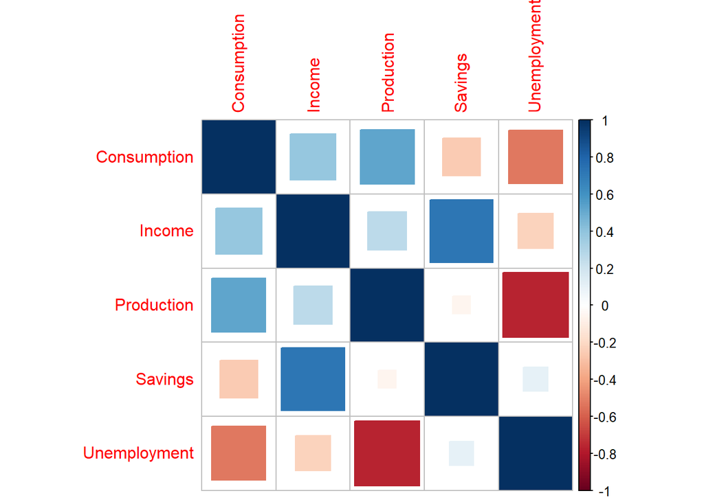

```r
library(corrplot)
cor(uschange[,2:6]) %>% corrplot(method = "square")
```

```r
# Ajusta un modelo de regresión lineal (simple) Y~X
# Y : Variable respuesta Consumption
# X : Variable explicativa (la que tú elijas)
# Y guardarla dentro de una variable llamada "reg"

reg <- lm(uschange$Consumption~uschange$Savings)

# Analiza los resultados usando la función summary a la variable reg
summary(reg)
```

```
##
## Call:
## lm(formula = uschange$Consumption ~ uschange$Savings)
##
## Residuals:
##      Min       1Q   Median       3Q      Max
## -2.85735 -0.33216  0.01652  0.31727  1.77791
##
## Coefficients:
##                  Estimate Std. Error t value Pr(>|t|)
## (Intercept)       0.76153    0.04422  17.220  < 2e-16 ***
## uschange$Savings -0.01368    0.00368  -3.717 0.000263 ***
## ---
## Signif. codes:  0 '***' 0.001 '**' 0.01 '*' 0.05 '.' 0.1 ' ' 1
##
## Residual standard error: 0.6181 on 196 degrees of freedom
## Multiple R-squared:  0.06586,    Adjusted R-squared:  0.06109
## F-statistic: 13.82 on 1 and 196 DF,  p-value: 0.0002627
```

Para este ejercicio se escogió la variable Savings como variable explicativa. En el resultado anterior podemos observar que es una variable muy significativa aún en el nivel más bajo de 0 (los tres asteríscos). En términos generales, el modelo dice que conforme la variable Saving aumenta, la variable Consumption disminuya.  
**Elabora una gráfica de dispersión de Consumo (eje y) VS Variable explicativa (eje x). Incorpora una línea que indique el modelo nulo (promedio de consumo) yla línea de regresión**

[figure not shown]

```r
# Hagamos una gráfica de dispersión
plot(x = uschange$Savings,
     y = uschange$Consumption,
     col = c("orangered1"),
     pch = 18,
     main = "Consumo VS Ahorros",
     xlab = "Dinero consumido",
     ylab = "Ahorros")

# abline pinta sobre el gráfico actual una recta del tipo y = a + bx

# Pintemos el MODELO NULO, es decir la media de y
abline(a = mean(uschange$Consumption), b = 0, col = "blue", lwd = 2)

# Línea de regresión
coefs <- coef(reg)
abline(a = coefs[1], b = coefs[2], col = "orangered1", lwd = 4)
```

**Guarda las predicciones y residuales dentro del DF y labora una regresión de residuales ~ predicciones**

```r
uschange$pred_cons <- reg$fitted.values
uschange$res_cons <- reg$residuals

reg_res_cons <- lm(uschange$res_cons~uschange$pred_cons) # "~" Regresión de los residuales con base en predicciones
reg_res_cons
```

```
##
## Call:
## lm(formula = uschange$res_cons ~ uschange$pred_cons)
##
## Coefficients:
##        (Intercept)  uschange$pred_cons
##         -1.643e-16           2.054e-16
```

```r
summary(reg_res_cons)
```

```
##
## Call:
## lm(formula = uschange$res_cons ~ uschange$pred_cons)
##
## Residuals:
##      Min       1Q   Median       3Q      Max
## -2.85735 -0.33216  0.01652  0.31727  1.77791
##
## Coefficients:
##                      Estimate Std. Error t value Pr(>|t|)
## (Intercept)        -1.643e-16  2.045e-01       0        1
## uschange$pred_cons  2.054e-16  2.690e-01       0        1
##
## Residual standard error: 0.6181 on 196 degrees of freedom
## Multiple R-squared:  4.826e-33,  Adjusted R-squared:  -0.005102
## F-statistic: 9.459e-31 on 1 and 196 DF,  p-value: 1
```

**Elabora el gráfico de residuales VS predicciones incluyendo la línea de regresión**

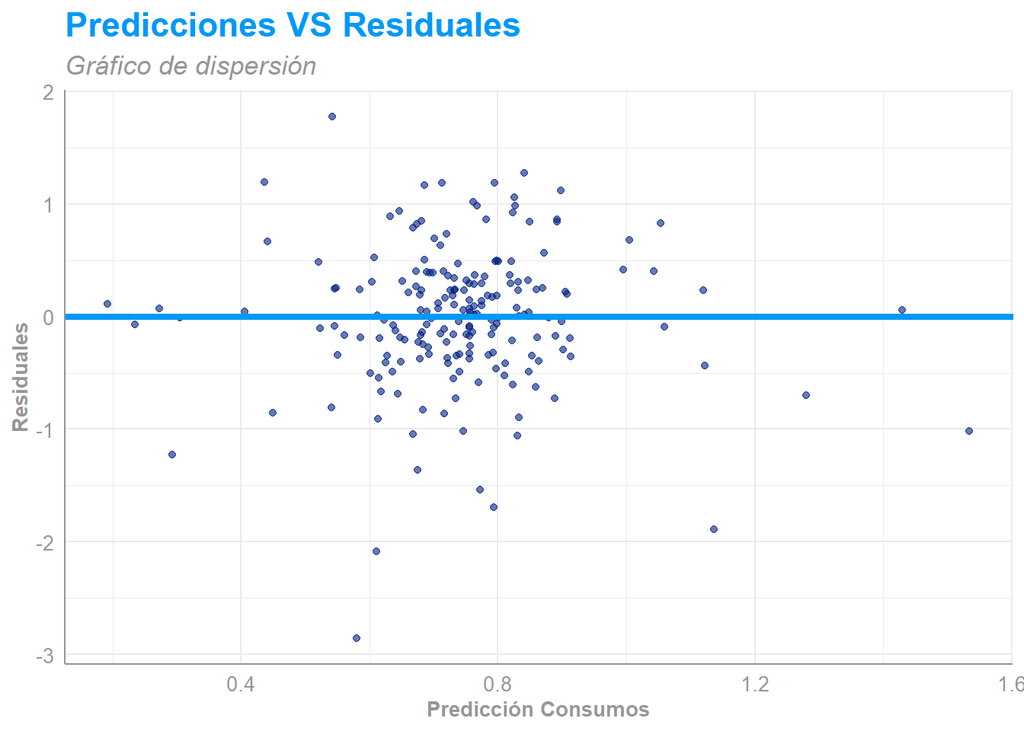

```r
uschange %>% ggplot(aes(x = uschange$pred_cons, y = uschange$res_cons)) + geom_point(alpha = 0.6, color = "#001F82") +
  geom_abline(intercept = coef(reg_res_cons)[1], slope = coef(reg_res_cons)[2], color = "#0099F8", size = 1.5)+
  labs(title = "Predicciones VS Residuales",
       subtitle = "Gráfico de dispersión",
       x = "Predicción Consumos",
       y = "Residuales") +
  theme_minimal() +
  theme(
    plot.title = element_text(color = "#0099F8",
                              size = 17,
                              face = "bold"),
    plot.subtitle = element_text(color = "#969696", size = 13, face = "italic"),
    axis.title = element_text(color = "#969696",
                              size = 10,
                              face = "bold"),
    axis.text = element_text(color = "#969696", size = 10),
    axis.line = element_line(color = "#969696")
  )
```

El intercepto y el coeficiente de las predicciones es prácticamente 0, junto con que el p-value es igual a 1 esto quiere decir que las predicciones y los residuales no están relacionados.

## Regresión multiple

**Elabora un modelo de regresión múltiple cuya variable (Y) dependiente sea Consumo utilizando dos variables explicativas (las que sean de tu elección)**

```r
reg_mult <- lm(uschange$Consumption~uschange$Savings + uschange$Income)

# Analiza los resultados utilizando la función summary
summary(reg_mult)
```

```
##
## Call:
## lm(formula = uschange$Consumption ~ uschange$Savings + uschange$Income)
##
## Residuals:
##      Min       1Q   Median       3Q      Max
## -0.96934 -0.14829 -0.01167  0.14240  1.41274
##
## Coefficients:
##                  Estimate Std. Error t value Pr(>|t|)
## (Intercept)       0.21543    0.03393   6.349 1.49e-09 ***
## uschange$Savings -0.05901    0.00282 -20.927  < 2e-16 ***
## uschange$Income   0.83664    0.03748  22.324  < 2e-16 ***
## ---
## Signif. codes:  0 '***' 0.001 '**' 0.01 '*' 0.05 '.' 0.1 ' ' 1
##
## Residual standard error: 0.3286 on 195 degrees of freedom
## Multiple R-squared:  0.7373, Adjusted R-squared:  0.7346
## F-statistic: 273.6 on 2 and 195 DF,  p-value: < 2.2e-16
```

Para la regresión multiple se tomaron las variables Savings (la misma que el modelo pasado) y la variable Income. En el resultado anterior podemos observar ambas variables son muy significativas aún en el nivel más bajo de 0 (los tres asteríscos). En términos generales, el modelo dice que si fijamos la variable Income, conforme la variable Saving aumenta, la variable Consumption disminuya; mientras que al fijar la variable Savings, conforme la variable Income aumenta, la variable Consumption aumenta.

**Guarda las predicciones y residuales dentro del DF y elabora una regresión de residuales ~ predicciones para el modelo múltiple**

```r
uschange$pred_cons <- reg_mult$fitted.values
uschange$res_cons <- reg_mult$residuals

reg_res_cons <- lm(uschange$res_cons~uschange$pred_cons) # "~" Regresión de los residuales con base en predicciones
reg_res_cons
```

```
##
## Call:
## lm(formula = uschange$res_cons ~ uschange$pred_cons)
##
## Coefficients:
##        (Intercept)  uschange$pred_cons
##         -1.356e-17           2.888e-17
```

```r
summary(reg_res_cons)
```

```
##
## Call:
## lm(formula = uschange$res_cons ~ uschange$pred_cons)
##
## Residuals:
##      Min       1Q   Median       3Q      Max
## -0.96934 -0.14829 -0.01167  0.14240  1.41274
##
## Coefficients:
##                      Estimate Std. Error t value Pr(>|t|)
## (Intercept)        -1.356e-17  3.930e-02       0        1
## uschange$pred_cons  2.888e-17  4.264e-02       0        1
##
## Residual standard error: 0.3278 on 196 degrees of freedom
## Multiple R-squared:  1.356e-32,  Adjusted R-squared:  -0.005102
## F-statistic: 2.658e-30 on 1 and 196 DF,  p-value: 1
```

**Elabora un Gráfico de residuales contra predicciones para el modelo múltiple**

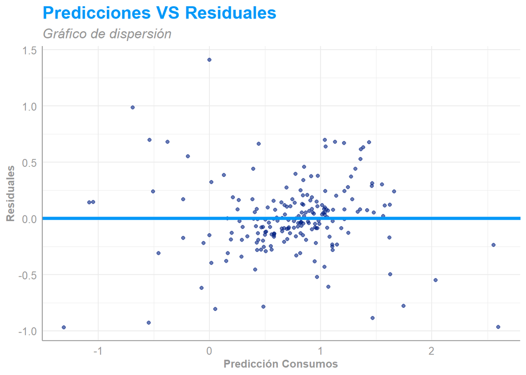

```r
uschange %>% ggplot(aes(x = uschange$pred_cons, y = uschange$res_cons)) + geom_point(alpha = 0.6, color = "#001F82") +
  geom_abline(intercept = coef(reg_res_cons)[1], slope = coef(reg_res_cons)[2], color = "#0099F8", size = 1.5)+
  labs(title = "Predicciones VS Residuales",
       subtitle = "Gráfico de dispersión",
       x = "Predicción Consumos",
       y = "Residuales") +
  theme_minimal() +
  theme(
    plot.title = element_text(color = "#0099F8",
                              size = 17,
                              face = "bold"),
    plot.subtitle = element_text(color = "#969696", size = 13, face = "italic"),
    axis.title = element_text(color = "#969696",
                              size = 10,
                              face = "bold"),
    axis.text = element_text(color = "#969696", size = 10),
    axis.line = element_line(color = "#969696")
  )
```

El intercepto y el coeficiente de las predicciones es prácticamente 0, junto con que el p-value es igual a 1 esto quiere decir que las predicciones y los residuales no están relacionados.  
**Realiza una comparación de ambos modelos utilizando criterios de información**

```r
library(broom)

glance(reg)
```

```
## # A tibble: 1 × 12
##   r.squared adj.r.squared sigma statistic  p.value    df logLik   AIC   BIC
##       <dbl>         <dbl> <dbl>     <dbl>    <dbl> <dbl>  <dbl> <dbl> <dbl>
## 1    0.0659        0.0611 0.618      13.8 0.000263     1  -185.  375.  385.
## # ℹ 3 more variables: deviance <dbl>, df.residual <int>, nobs <int>
```

```r
glance(reg_mult)
```

```
## # A tibble: 1 × 12
##   r.squared adj.r.squared sigma statistic  p.value    df logLik   AIC   BIC
##       <dbl>         <dbl> <dbl>     <dbl>    <dbl> <dbl>  <dbl> <dbl> <dbl>
## 1     0.737         0.735 0.329      274. 2.51e-57     2  -59.1  126.  139.
## # ℹ 3 more variables: deviance <dbl>, df.residual <int>, nobs <int>
```

**Tras el análisis propuesto, ¿cuál de los dos modelos elegirías?¿Por qué?**